# Desconstruindo a Violência Institucional na Atenção às Pessoas em Situação de Rua

Hernany Gomes de Castro | MPDFT

07 e 08 de novembro de 2024

# Acesse a Apresentação

[figure not shown]

# Começando

- Por favor, [clique e preencha](https://docs.google.com/forms/d/e/1FAIpQLSduUlX2KcPnNfPWq9MZ4WiqeCK7qMjO7uLekFxobijv0LbMOQ/closedform)
- [Notas coletivas](https://docs.google.com/document/d/1emwF5ngutl6OlkNLo3cniE7fNO38v6mEDVMMT9oFijE/edit?tab=t.0) do curso

# Introdução

- Desconstruir a violência institucional na atenção às pessoas em situação de rua
- Quais são as nossas expectativas?

# Objetivos

- Compreender o caráter relacional da situação de rua.
- Desenvolver uma compreensão sobre a qualidade das políticas públicas para pessoas em situação de rua.
- Compreender como a violência institucional afeta a qualidade das políticas públicas para pessoas em situação de rua.
- Identificar barreiras atitudinais na atenção às pessoas em situação de rua nas políticas públicas.
- Discutir estratégias para enfrentar barreiras atitudinais.

# Metodologia

- Apresentação e discussão de resultados de pesquisas realizadas sobre a situação de rua
  - Aula 1 (3 horas): Abordagem relacional da situação de rua
  - Aula 2 (3 horas): Qualidade das políticas públicas para pessoas em situação de rua
  - Aula 3 (3 horas): Violência institucional contra pessoas em situação de rua
- Principais Referências:

CASTRO, H. G (2024). Guia sobre a Situação de Rua. In: MPDFT (no prelo). Brasília, 2024

[CASTRO, H G (2024). Plano Social Teórico do Trânsito da Situação de Rua: Analisando Componentes Principais da Variação Quantitativa de Pessoas em Situação de Rua no Distrito Federal no ano 2023. In SciELO Preprints.](https://doi.org/10.1590/SciELOPreprints.10156)

[CASTRO, H G; ROCHA, E F (2024). Situação de rua, vínculos sociais e as políticas públicas de saúde e de assistência social. Serviço Social & Sociedade, v. 147, p. e, 13 set. 2024.](https://www.scielo.br/j/sssoc/a/3K4H63z5jwKhbFrqdTt78rP/?lang=pt)

[CASTRO, H G (2023). Vínculos de (sub)cidadania: um estudo de caso sobre os laços sociais de pessoas em situação de rua com as políticas públicas de saúde e de assistência social em São Sebastião-DF.2023. Dissertação (Mestrado) – Programa de Pós-Graduação em Sociologia, Universidade de Brasília, Brasília, 2023.](https://repositorio.unb.br/jspui/handle/10482/49031)

# O que é Situação de Rua?

- Fenômeno multidimensional
- Ponto extremo num continuum de situações em que se deteriora a articulação entre habitação e vínculos sociais
- Trabalho e pobreza se articulam a formas de deterioração dos vínculos sociais
- Condição temporária de rompimento ou fragilização de vínculos e de desqualificação social
- Dependência de assistência para retomar vínculos e a requalificação social

# Números da Situação de Rua no Distrito Federal

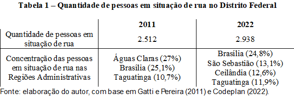

- A Codeplan (2022) identificou 244 crianças e adolescentes, 563 mulheres e 2.375 homens. A tabela 2, a seguir, resume a distribuição por faixa etária.

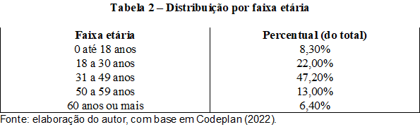

- O Ministério dos Direitos Humanos e da Cidadania registrou 7.924 pessoas em situação de rua no Distrito Federal em 2023 (Brasil, 2023). A pesquisa identificou 01 a cada 1.000 pessoas no Brasil vivendo em situação de rua em 2022. **O DF é a unidade da federação com maior percentual em relação à população total, registrando quase 03 pessoas em situação de rua a cada 1.000 habitantes.**
- A esses dados quantitativos, pesquisas qualitativas têm chamado atenção para a heterogeneidade da população em situação de rua (Castro, 2023; Castro e Rocha, 2024).
- A heterogeneidade pode ser contextualizada mais adequadamente a partir da associação entre múltiplas variáveis, como tempo em diferentes situações de endereço e laços sociais.
- As pesquisas permitem inferir que a situação de rua é marcada por hierarquias sociais, além de institucionalmente mediada por políticas públicas, destacadamente as de assistência social, saúde e segurança pública.
- A mediação, contudo, nem sempre se dá da maneira que é esperada pela concepção dessas políticas públicas.

# Variação Quantitativa nas RA’s do DF em 2023

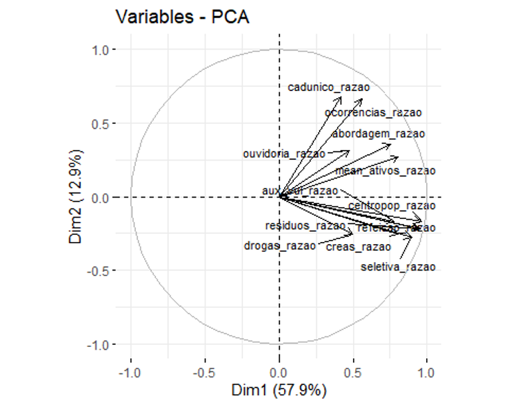

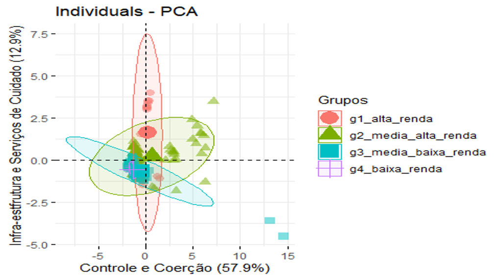

# Qualidade nas políticas públicas para Pessoas em Situação de Rua

- As políticas públicas são vínculos sociais específicos que regulam relações de assistência
- Estigmas e benefícios sociais
- Alivío precário da pobreza com políticas seletivas
- A combinação de estigma e seletividade cria o ambiente para o desenvolvimento da sub-cidadania
- A discricionariedade na distribuição de atendimento em serviços e em benefícios
- A desigualdade de acesso aos direitos sociais gera o reconhecimento limitado da cidadania

# Acesso e Seletividade

- O endereço como mecanismo de regulação dos laços sociais

#### Gráfico 1. Situação de endereço e os benefícios da União

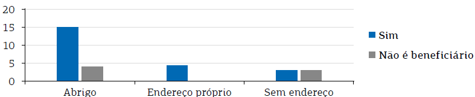

#### Gráfico 2. Situação de endereço e os benefícios do Governo do Distrito Federal

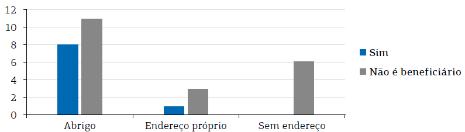

#### Gráfico 3. Situação de endereço e o atendimento no Suas

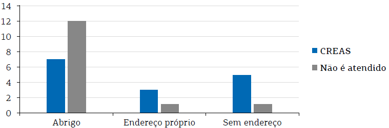

#### Gráfico 4. Situação de endereço e o Atendimento na Atenção Básica do SUS

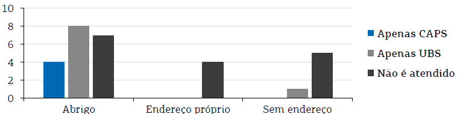

#### Figura 1. Diagrama das transições entre situações de endereço

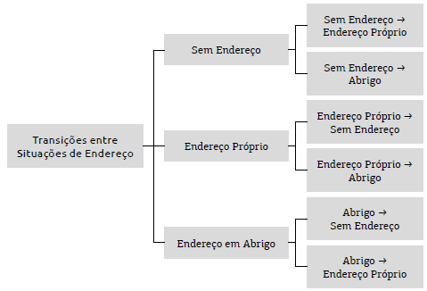

# Regime de Vínculos Sociais na Situação de Rua

Dendograma das Classes na Classificação Hierárquica Descendente - CHD

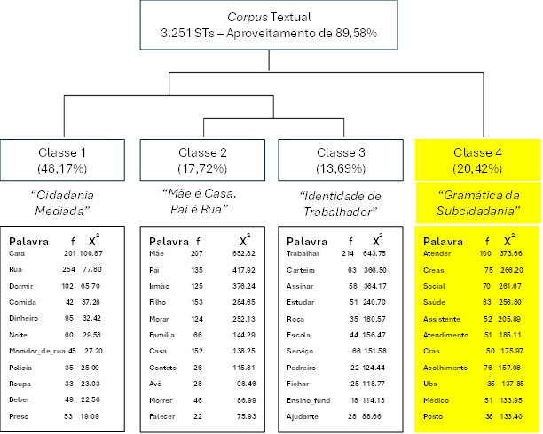

Análise Fatorial por Correspondência

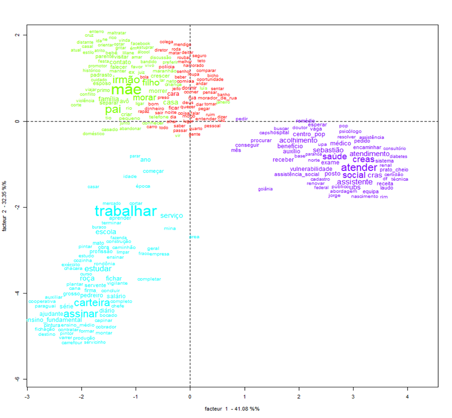

# Violência Institucional na Atenção às Pessoas em Situação de Rua

- Gontijo et al (2023) constatam que a atenção básica à saúde da pessoa em situação de rua requer maior investimento profissional e de políticas transversais, com a construção de vínculos e o desenvolvimento de ações de promoção da saúde se constituindo como desafios no âmbito da Atenção Primária à Saúde. Os autores identificaram que estudos relatando experiências positivas das pessoas em situação de rua na atenção primária à saúde são incipientes, muito em razão das dificuldades de acesso em diversos países, como da falta de preparo, baixa sensibilização e da falha de comunicação dos profissionais de saúde. Os resultados encontrados apontam para a não efetivação da atenção integral para pessoas em situação de rua na atenção primária.
- Machado (2021): a estigamtização da eCR no próprio sistema de saúde aumenta o obstáculo para o exercício do direito à saude pelas pessoas em situação rua. A Ubs como um espaço a ser ocupado pela eCR denota o distanciamento de um serviço criado para aproximar. A resolutividade da eCR está associado ao estigma contra a pop rua.
- Jordão (2021) discute os usos do território da cidade pela população em situação de rua, tomando Campo dos Goytacazes/Rj como campo de pesquisa. O autor sugere que o serviços socioassitencias oferecidos às pessoas em situação de rua na cidade apresentam exigências formais conflitantes com as necessidades e características das pessoas em situação de rua. Como exemplo, cita-se que a necessidade de escolher entre abrigo ou trabalho. Jordão mostra, ainda, como o estigma é evidenciado nos conflitos urbanos que envolvem as pessoas em situação de rua.
- Valle e Vecchia (2020) destacam a relevância da moradia para o cuidado integral e das redes sociais e comunitárias para o reestabelecimento da saúde das pessoas em situação de rua. Sobretudo, nos municípios de pequeno porte onde as políticas sociais se efetivam mais lenta e gradualmente do que nas cidades de médio e grande porte. O estudo enfatiza o modo com a PSR usa os serviços de saúde, sobretudo, as alternativas que desenvolve e as redes que aciona para autocuidado diante do direito negado.
- Teixeira et al (2020) identificam que o comportamento de profissionais da saúde constitui uma barreira para acesso aos cuidados de saúde no SUS pelas pessoas em situação de rua na cidade do Rio de Janeiro, mediante exigências burocráticas de documentação, condicionalidades indevidas sem motivação aparente ou atendimento desqualificado devido à aparência pessoal.O estudo discute como as percepções estigmatizadas e estigmatizantes da psr e dos profissionais de saúde restingem ou bloqueiam o acesso aos cuidados de saúde.
- Oliveira e Guizardi (2020) encontraram recorrências de práticas e concepções preconceituosas na atuação das equipes de saúde que atendem pessoas em situação de rua no Distrito Federal. Os autores também identificaram restrições à participação das pessoas em situação de rua na elaboração das políticas distritais voltadas para esse público.
- Honorato e Oliveira (2020) destacam a fragilidade da população em situação de rua diante da Covid, acompanhando a tendência de propensão desse público à uma mortalidade maior que a da população em geral, independente da causa. Os autores discutem como a dependência do Estado pelas pessoas em situação de rua gerou insegurança e agravou o risco de mortalidade por Covid, apontando problemas relacionados à prevenção, intervenção, conscientização, infraestrutura e aos trabalhadores das políticas públicas de saúde e de assistência social.
- Pimenta (2019) mostram como o estigma é uma característica presente e marcante na relação das pessoas em situação de rua com a sociedade em geral, especialmente, com agentes do Estado. Ao investigar os processos de estigmatização e de produção da invisibilidade social das pessoas em situação de rua em Porto Alegre, o autor identificou que a maioria das pessoas em situação de rua na cidade não utiliza os serviços de acolhimento, em razão da estigmatização e da discriminação das equipes. Entre as questões envolvidas, a rígidez das regras e a forma de tratamento pelas equipes, além da burocracia para conseguir a vaga, constituem os principais motivos para evitação desse serviço. Outro resultado a ser destacado é relativo à sensação de vulnerabilidade, desconfiança, desrespeito e medo que a situação de rua provoca, sobretudo, na relação com agentes do Estado (a polícia, principalmente), expressando constrangimentos para exercício dos direitos civis.
- Pinho et al (2019) identificam que embora a inclusão produtiva seja uma importante estratégia para acesso ao mercado de trabalho, portanto, uma forma de contribuir para a superação da situação de rua, são necessárias ações coletivas e intersetoriais que reconheçam o acesso ao trabalho como direito das pessoas em situação de rua. Os autores argumentam que a individualização de problemas sociais na política pública de assistência social, tais como a baixa escolaridade, a carência de capacitação profissional, o uso abusivo de álcool e outras drogas, os transtornos mentais, o histórico prisional e a dificuldade de adesão e de gestão financeira, como o preconceito e a discriminação, responsabilizam o indivíduo por sua inserção no mercado de trabalho e dificultam o acesso e a manutenção da pessoa em situação de rua em atividades laborais, à exemplo das ações de inclusão produtiva.
- Mendes et al (2019) afirma a existência de uma tendência nas abordagens contemporâneas de análise e compreensão das particularidades de vida dessas pessoas, sobretudo, na saúde pública, que prioriza um enfoque individualista e patologizante (nesse caso, da doença como objeto).Os autores argumentam que o uso e o abuso de drogas, como os sintomas ou quadros de adoecimento psíquico, são considerados fatores de causalidade da vida nas ruas em muitos estudos, os quais ignoram a condição de pobreza, a trajetória de vida e marcadores sociais como classe e raça.Merece destaque o achado segundo o qual os estudos latino-americanos pouco trabalham a categoria raça, que aparece como categoria sociodemográfica e em interseção com outras categorias, mas nunca como categoria principal de análise nos estudos realizados na área da saúde, à semelhança das pesquisas nos EUA onde aparece como informação estatística.
- A revisão realizada por Sicari e Zanella (2018) mostra que o aumento das pesquisas sobre a situação de rua não promoveu a construção de indicadores para as políticas públicas. Em relação às interlocuções entre saúde e assistência social, os estudos encontrados sugerem baixo grau de articulação e intersetorialidade, como de alcance das pessoas em situação de rua, além de um viés caritativo, assistencialista e filantrópico nas prestações de serviço. Em outras palavras, as pesquisas sugerem a questão do acesso ao SUS e ao SUAS como objeto de preocupação. A priorização e a intersetorialidade voltadas às pessoas em situação de rua é mais formal do que uma prática.
- Rodrigues et al (2018) retratam como a situação de rua metamorfosea a identidade das pessoas, prendendo-as em conflitos identitários pela repetição do preconceito e da discriminação como formas de reconhecimento social.
- Souza et al (2017) informam resultados relativos à resistência e evitação das equipes de consultório na rua do serviço de saúde municipal pelas pessoas em situação de rua, devido a ausência de vínculos.
- Fiorati et al (2017) identificaram iniquidades de ordem econômica, educacional, familiar e relacional, como pobreza e extrema pobreza, analfabetismo ou baixa escolaridade, atividades laborais desqualificadas e de baixa renda e baixo capital social, vínculos sociais marcados pela violência, transmitidas geracionalmente em famílias de pessoas em situação de rua em Ribeirão Preto-SP, implicando um cotidiano marcado por pobreza e exclusão, isolamento e rupturas das redes sociais, doenças e uso de álcool e outras drogas.A indivualização moral do problema social nas políticas sociais culpabiliza a pessoa e não reconhece os condicionamentos históricos e sociais.
- Serafino e Luz (2015) analisando o funcionamento da assistencia social no Rio de Janeiro sugerem uma frágil intersetorialidade e integração entre os serviços na cidade, acentuada por ações coercitivas de zeladoria, revelando uma implementação residual e fragmentada da Política Nacional para a População em Situação de Rua. As autoras identificaram que os encaminhamentos realizados pelo CREAS não são respondidos por outro serviços socioassistenciais, denotando ausência de articulação, como as abordagens realizadas diretamente na rua pelo serviço de abordagem são organziadas a partir das demandas apresentadas pela Ouvidoria, além de uma priorização do acolhimento das pessoas em situação de rua como resultado da política pública.
- Paiva et al (2015) enfatizam a baixa produção de conhecimento sobre a população em situação de rua na atenção básica de saúde. As autoras avaliam as políticas sociais existentes como compensatórias e assistencialistas, considerando seus problemas de acesso, de caráter paliativo e higienista, uma atenção à saúde centrada em modelo unicausal ou multicausal da doença, resultando em ações assistencialistas e medicalizantes, de modo a não garantir o direito à saúde.
- Ferraz e MAchado (2014) Discute a remoção de pessoas durante as olimpíadas no Rio de Janeiro. Muito interessante o estudo porque essas pessoas foram transformadas em moradores de rua. Embora numa outra realidade, do Rio de Janeiro, é possível traçar um paralelo com a mudança do fluxo das pessoas em situação de rua para regiões administrativas periféricas do DF, como São Sebastião.
- Fernandes et al (2007) estudo aborda os problemas vividos por psr idosos, apontando as fragilidades de vínculos de residência e com a família. Identifica as fragilidades de vínculos. Estudo em inglês, mas feito em são paulo.
- Bretas et al (2010) O artigo discute os problemas da vida na rua para um idoso. É um estudo que exemplifica um dos extremos do drama da vida na rua.

# Referência Bibliográfica

ANDRADE, R. D. et al. O acesso aos serviços de saúde pela População em Situação de Rua: uma revisão integrativa. Saúde em Debate, v. 46, n. 132, p. 227–239, mar. 2022.

CARVALHO, J. M. DE. Cidadania no Brasil: o longo caminho. Rio de Janeiro: Civilização Brasileira, 2001. ___. Os bestializados: o Rio de Janeiro e a República que não foi. 4a edição ed. São Paolo: Companhia das letras, 2019.

CASTRO, H G. Caderno de Campo da Rua 48. Brasília: Universidade de Brasília, 2022.

CASTRO, H G. Quando o Trabalho vira Passatempo. Arquivos do CMD -20 anos, v. 11, n. 1, p. 250–289, 2023.

[CASTRO, H G; ROCHA, E F (2024). Situação de rua, vínculos sociais e as políticas públicas de saúde e de assistência social. Serviço Social & Sociedade, v. 147, p. e, 13 set. 2024.](https://www.scielo.br/j/sssoc/a/3K4H63z5jwKhbFrqdTt78rP/?lang=pt)

[CASTRO, H G (2023). Vínculos de (sub)cidadania: um estudo de caso sobre os laços sociais de pessoas em situação de rua com as políticas públicas de saúde e de assistência social em São Sebastião-DF.2023. Dissertação (Mestrado) – Programa de Pós-Graduação em Sociologia, Universidade de Brasília, Brasília, 2023.](https://repositorio.unb.br/jspui/handle/10482/49031)

CODEPLAN, G. DO D. F. Perfil da População em Situação de Rua no DF. Brasília: CODEPLAN, 2022. Disponível em: https://www.codeplan.df.gov.br/wp-content/uploads/2021/12/Relatorio-Perfil-da-Populacao-em-Situacao-de-Rua-no-Distrito-Federal.pdf. Acesso em: 1 jul. 2022.

FIORATI, R. C. et al. As rupturas sociais e o cotidiano de pessoas em situação de rua: estudo etnográfico. Revista Gaúcha de Enfermagem, v. 37, 17 jul. 2017. Folha de S.Paulo - Moradores de rua sofrem ataque em série - 20/08/2004. Disponível em: https://www1.folha.uol.com.br/fsp/cotidian/ff2008200401.htm. Acesso em: 18 ago. 2023.

GATTI, B. PAPAIZ; PEREIRA, C. P. Projeto Renovando a Cidadania. Brasília: Gráfica Exec., 2011.

GONTIJO, L. A.; SILVA, B. M. DA; VIEGAS, S. M. DA F. Atenção à saúde de pessoas em situação de rua no cotidiano da atenção primária: scoping review. Saúde em Debate, v. 47, p. 316–332, 30 jun. 2023.

HONORATO, B. E. F.; OLIVEIRA, A. C. S. População em situação de rua e COVID-19. Revista de Administração Pública, v. 54, p. 1064–1078, 28 ago. 2020.

JORDÃO, D. A POPULAÇÃO EM SITUAÇÃO DE RUA E OS USOS DO TERRITÓRIO EM CAMPOS DOS GOYTACAZES/RJ. Revista Espaço e Geografia, v. 24, n. 1, p. 12–36, 2021.

MACHADO, M. P. M. As práticas dos Consultórios na Rua: perspectivas para o monitoramento e avaliação do campo. Rio de Janeiro: Universidade Federal do Rio de Janeiro, 2021.

MORAES, A. DE. DECISÃO ADPF 976 MC/DFSuperior Tribunal Federal - STF, , 25 jul. 2003. Disponível em: https://www.stf.jus.br/arquivo/cms/noticiaNoticiaStf/anexo/ADPF976MC1.pdf. Acesso em: 10 ago. 2023

MPDFT. Recomendação_no_3_NED.pdf. Brasília: Ministgério Público do Distrito Federal e Territórios, 2021. Disponível em: https://www.mpdft.mp.br/portal/images/Recomendac%CC%A7a%CC%83o_n%C2%BA_3_NED.pdf. Acesso em: 10 jul. 2022.

NATALINO, M. ESTIMATIVA DA POPULAÇÃO EM SITUAÇÃO DE RUA NO BRASIL (2012-2022) - Publicação Preliminar. Brasília: Instituto de Pesquisa Econômica Aplicada (Ipea), 2022. Disponível em: https://repositorio.ipea.gov.br/bitstream/11058/11604/1/NT_Estimativa_da_Populacao_Publicacao_Preliminar.pdf. Acesso em: 26 jun. 2023.

NATALINO, M. A. C. A REDISTRIBUIÇÃO E SEUS DESCONTENTES: PERCEPÇÕES SOCIAIS SOBRE POBREZA, DESIGUALDADE E PROGRAMAS DE TRANSFERÊNCIA DE RENDA. Rio de Janeiro: Universidade Federal do Rio de Janeiro, 2021.

NUNES, N. R. DE A. et al. POPULAÇÃO EM SITUAÇÃO DE RUA EM TEMPOS DE PANDEMIA DA COVID-19 (ebook). Rio de Janeiro: PUC-Rio, 2021.

OLIVEIRA, A.; LUBE GUIZARDI, F. A construção da política para inclusão de pessoas em situação de rua: avanços e desafios da intersetorialidade nas políticas de saúde e assistência social. Saúde e Sociedade, v. 29, 17 ago. 2020.

PAIVA, I. K. S. DE et al. Direito à saúde da população em situação de rua: reflexões sobre a problemática. Ciência & Saúde Coletiva, v. 21, p. 2595–2606, ago. 2016.

PIMENTA, M. DE M. Pessoas em situação de rua em Porto Alegre: Processos de estigmatização e invisibilidade social. Civitas - Revista de Ciências Sociais, v. 19, p. 82–104, 8 abr. 2019.

PINHO, R. J. DO; PEREIRA, A. P. F. B.; LUSSI, I. A. DE O. População em situação de rua, mundo do trabalho e os centros de referência especializados para população em situação de rua (centro pop): perspectivas acerca das ações para inclusão produtiva. Cadernos Brasileiros de Terapia Ocupacional, v. 27, p. 480–495, 12 set. 2019.

SERAFINO, I.; LUZ, L. C. X. Políticas para a população adulta em situação de rua: questões para debate. Revista Katálysis, v. 18, p. 74–85, jun. 2015. SICARI, A. A.; ZANELLA, A. V. Pessoas em Situação de Rua no Brasil: Revisão Sistemática. Psicologia: Ciência e Profissão, v. 38, n. 4, p. 662–679, out. 2018.

TEIXEIRA, M. B. et al. Os invisibilizados da cidade: o estigma da População em Situação de Rua no Rio de Janeiro. Saúde em Debate, v. 43, p. 92–101, 13 jul. 2020.

TELLES, V. DA S. Pobreza e cidadania. 1a ed ed. São Paulo, SP, Brasil: Curso de Pós-Graduação em Sociologia, Universidade de São Paulo: Editora 34, 2001.

VALE, A. R. DO; VECCHIA, M. D. SOBREVIVER NAS RUAS: PERCURSOS DE RESISTÊNCIA À NEGAÇÃO DO DIREITO À SAÚDE. Psicologia em Estudo, v. 25, 15 jul. 2020.

Obrigado!

email: hernany1@gmail.com